**Finding the Regression**

Using the dataset prepared [here](https://github.com/Roctober92/senior_project_scripts/blob/master/data_prep/na_regression_prep.R) , the following outlines the [steps I made](https://github.com/Roctober92/senior_project_scripts/blob/master/snow_regress/na_regression_month_temp.R) to find a good regression for the data.

I first imported and made **training** and **test** datasets.

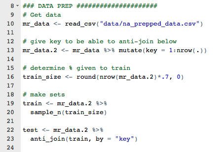

- SWE + Month + SWE:Month + avg_temp, .934 correlation

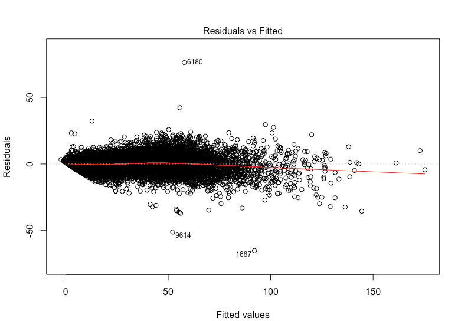

- Same model, SWE has a sqrt transformation, .925 correlation

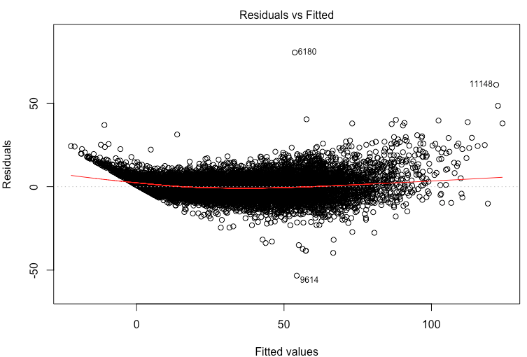

This model produces negative **snow depth** values, and has an unfavorable data shape.  
The squared residuals from the original model also show a megaphone shape. I did a Box Cox for a possible *Y transformation*.

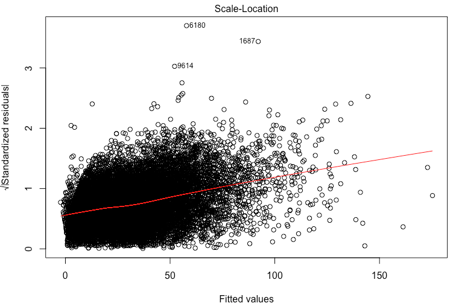

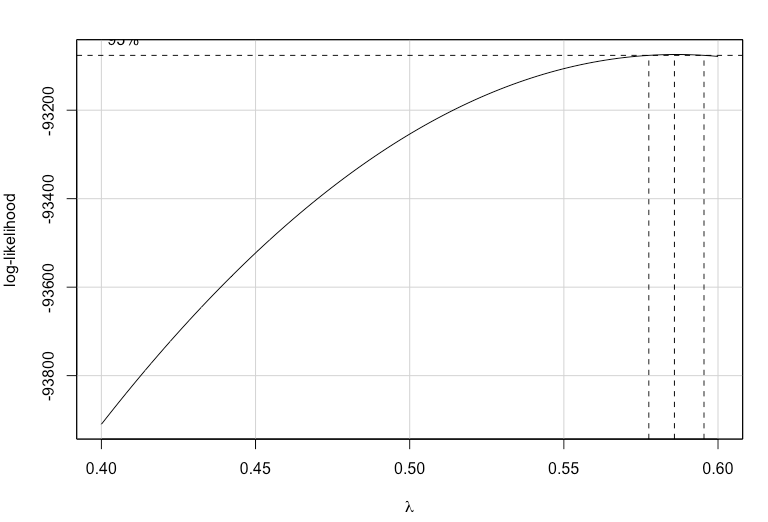

This suggests a .6 transformation, but I decided to do a .5, just for simplicity.

- SQRT(Depth) ~ SQRT(SWE) + Month + SQRT(SWE) + avg_temp, .94 correlation.

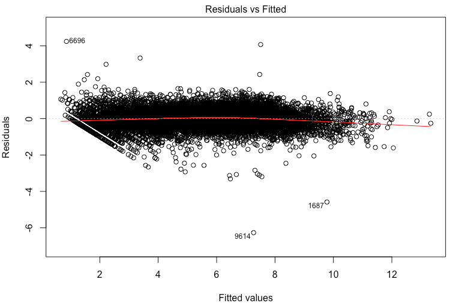

Best correlation, data is mostly linear. Interesting patterns in residuals. I decided to use this model. Megaphone shape greatly reduced.

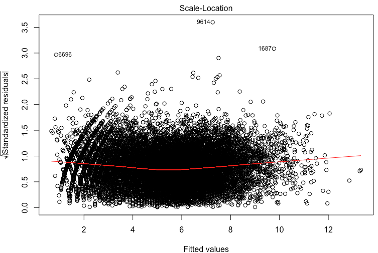

- Validation Set: .9405 correlation

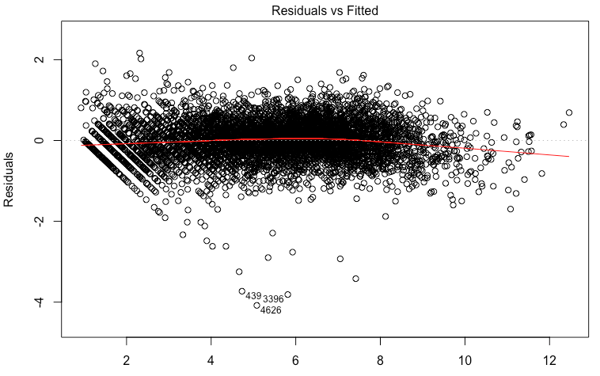

Model has similar linearity, and correlation, which helps us have confidence in that model has similar results for supposedly similar data, and that model wasn’t over-fitting first data.

- Full Dataset: .94 correlation

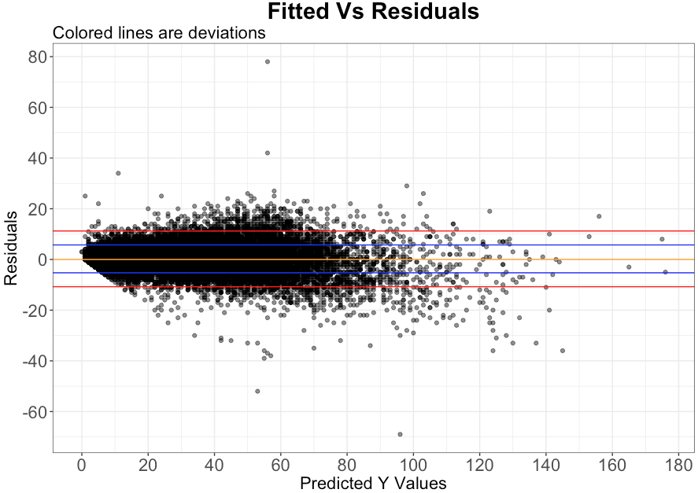

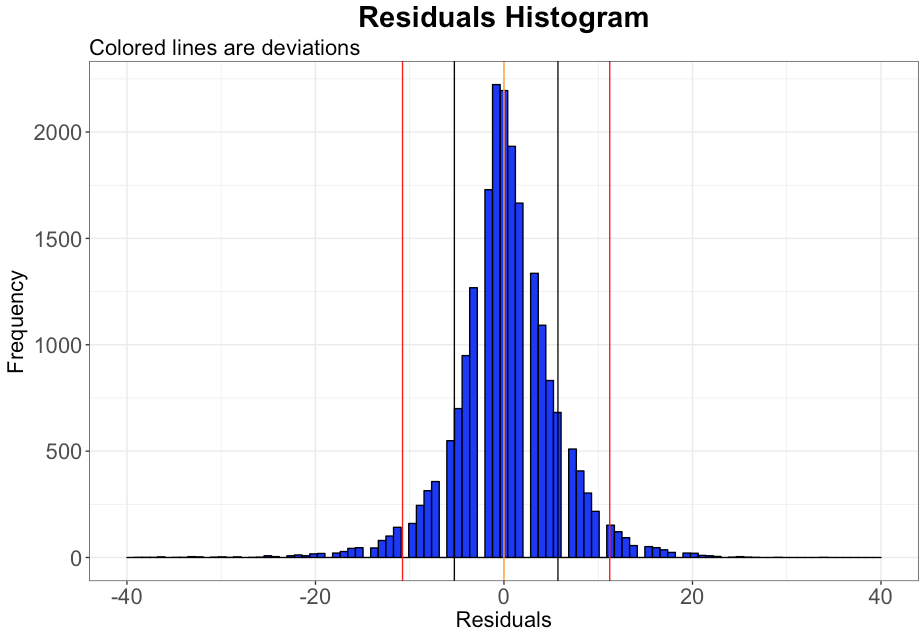

Residuals are almost normally distributed, just a little steep. But maybe the more important thing to take away this the model errors mostly within 5 of actual values.  
This model was used to predict the **missing snow depth values.**